# Practica Boxplot

Alberto Mengual

7/9/2021

# MINI EJERCICIO BOXPLOT - DATOS CUANTITATIVOS

Consiste en coger varios datasets de los famosos que tengan datos numericos y aplicarle el boxplot.

Creo que debería practicar con:

- datos cualitativos:
  - crosstable (para bidimensionales) - hecho en los mosaicos
  - diagrama de mosaico (para bidimensionales) - hecho
  - añadir a ftable un titulo y los totales y las relativas - PENDIENTE, me faltan los titulos y las acumuladas
  - evitar que se repitan los mosaicos - hecho
- ordinales:
  - sintaxis de cumsum() - hecho
  - añadir tablas a los gráficos de mosaico - hecho ( es de los cualitativos)
  - añadir tablas a los diagramas de barras - hecho
  - añadir tablas de frecuencias acumuladas - hecho
  - mejorar la estetica de crosstable??
  - intentar que salgan juntos los gráficos de frecuencias con sus acumuladas.- PENDIENTE
- cuantitativos:
  - añadir tablas a los diagramas de caja y bigotes totales -(hecho)
  - añadir tablas a los diagramas de cajas y bigotes agrupados - hecho(faltan los nombres)
  - agrupar los bigotes por factores - hecho
  - crear graficos con puntos de colores para las variables cualitativas que faltan, añadir tiulos al grafico y la leyenda - hecho
  - crear graficos y tablas (mas o menos hecho)
- repetir con el otro dataframe
- crear una plantilla de analisis descriptivo:
  - cambir dc por df

## RESUMEN TAREAS

- Hacerle un boxplot a cada uno de ellos,
- quitar las variables que no son numericas.
- Ponerle un titulo y sus respectivas etiquetas y algún color.
- Entender el concepto del bigote.

### IMPORTAR DATASETS

¿Cuales datasets voy a importar para este mini ejercicio? Iris y Datacrab Podía haber cogido cualquier otro, para ver los data frames disponibles usar la función data()

```r
dc = read.table("../data/datacrab.txt", header = TRUE, row.names = 1)
ir = iris

# convertir las variables categoricas a factores:
dc$color = factor(dc$color, ordered = FALSE)
dc$spine = factor(dc$spine, ordered = TRUE)
dc$satell = factor(dc$satell, ordered = FALSE)
```

### INFORMACIÓN BÁSICA DEL DATASET Y CREACION DE FACTORES

```r
head(dc)
```

```
##   color spine width satell weight
## 1     3     3  28.3      8   3050
## 2     4     3  22.5      0   1550
## 3     2     1  26.0      9   2300
## 4     4     3  24.8      0   2100
## 5     4     3  26.0      4   2600
## 6     3     3  23.8      0   2100
```

```r
str(dc)
```

```
## 'data.frame':    173 obs. of  5 variables:
##  $ color : Factor w/ 4 levels "2","3","4","5": 2 3 1 3 3 2 1 3 2 3 ...
##  $ spine : Ord.factor w/ 3 levels "1"<"2"<"3": 3 3 1 3 3 3 1 2 1 3 ...
##  $ width : num  28.3 22.5 26 24.8 26 23.8 26.5 24.7 23.7 25.6 ...
##  $ satell: Factor w/ 15 levels "0","1","2","3",..: 9 1 10 1 5 1 1 1 1 1 ...
##  $ weight: int  3050 1550 2300 2100 2600 2100 2350 1900 1950 2150 ...
```

```r
summary(dc)
```

```
##  color  spine       width          satell       weight
##  2:12   1: 37   Min.   :21.0   0      :62   Min.   :1200
##  3:95   2: 15   1st Qu.:24.9   3      :19   1st Qu.:2000
##  4:44   3:121   Median :26.1   4      :19   Median :2350
##  5:22           Mean   :26.3   1      :16   Mean   :2437
##                 3rd Qu.:27.7   5      :15   3rd Qu.:2850
##                 Max.   :33.5   6      :13   Max.   :5200
##                                (Other):29
```

### TRATAMIENTO DE LAS VARIABLES

#### Frecuencias absolutas de las variables cualitativas:

```r
tc = ftable(dc$color, dc$spine, dc$satell, dnn = c("Color","Spine", "Satell"))
tc
```

```
##             Satell  0  1  2  3  4  5  6  7  8  9 10 11 12 14 15
## Color Spine
## 2     1             2  0  1  0  1  1  2  0  1  1  0  0  0  0  0
##       2             0  0  0  1  0  0  1  0  0  0  0  0  0  0  0
##       3             1  0  0  0  0  0  0  0  0  0  0  0  0  0  0
## 3     1             8  3  0  1  2  6  1  1  1  0  0  0  0  1  0
##       2             5  0  0  0  2  0  1  0  0  0  0  0  0  0  0
##       3            13  8  6  8  8  5  6  2  3  1  1  1  0  0  1
## 4     1             0  0  0  1  1  0  0  0  0  1  0  0  0  0  0
##       2             2  0  0  1  1  0  0  0  0  0  0  0  0  0  0
##       3            16  5  2  5  3  2  2  1  0  0  1  0  0  0  0
## 5     1             1  0  0  0  0  0  0  0  0  0  0  0  0  0  0
##       2             1  0  0  0  0  0  0  0  0  0  0  0  0  0  0
##       3            13  0  0  2  1  1  0  0  1  0  1  0  1  0  0
```

```r
ftable(round(prop.table(table(dc$color, dc$spine, dc$satell)),2),
       dnn = c("Color","Spine", "Satell"))
```

```
##         0    1    2    3    4    5    6    7    8    9   10   11   12   14   15
##
## 2 1  0.01 0.00 0.01 0.00 0.01 0.01 0.01 0.00 0.01 0.01 0.00 0.00 0.00 0.00 0.00
##   2  0.00 0.00 0.00 0.01 0.00 0.00 0.01 0.00 0.00 0.00 0.00 0.00 0.00 0.00 0.00
##   3  0.01 0.00 0.00 0.00 0.00 0.00 0.00 0.00 0.00 0.00 0.00 0.00 0.00 0.00 0.00
## 3 1  0.05 0.02 0.00 0.01 0.01 0.03 0.01 0.01 0.01 0.00 0.00 0.00 0.00 0.01 0.00
##   2  0.03 0.00 0.00 0.00 0.01 0.00 0.01 0.00 0.00 0.00 0.00 0.00 0.00 0.00 0.00
##   3  0.08 0.05 0.03 0.05 0.05 0.03 0.03 0.01 0.02 0.01 0.01 0.01 0.00 0.00 0.01
## 4 1  0.00 0.00 0.00 0.01 0.01 0.00 0.00 0.00 0.00 0.01 0.00 0.00 0.00 0.00 0.00
##   2  0.01 0.00 0.00 0.01 0.01 0.00 0.00 0.00 0.00 0.00 0.00 0.00 0.00 0.00 0.00
##   3  0.09 0.03 0.01 0.03 0.02 0.01 0.01 0.01 0.00 0.00 0.01 0.00 0.00 0.00 0.00
## 5 1  0.01 0.00 0.00 0.00 0.00 0.00 0.00 0.00 0.00 0.00 0.00 0.00 0.00 0.00 0.00
##   2  0.01 0.00 0.00 0.00 0.00 0.00 0.00 0.00 0.00 0.00 0.00 0.00 0.00 0.00 0.00
##   3  0.08 0.00 0.00 0.01 0.01 0.01 0.00 0.00 0.01 0.00 0.01 0.00 0.01 0.00 0.00
```

#### Variables cualitativas y ordinales * Diagramas de mosaico

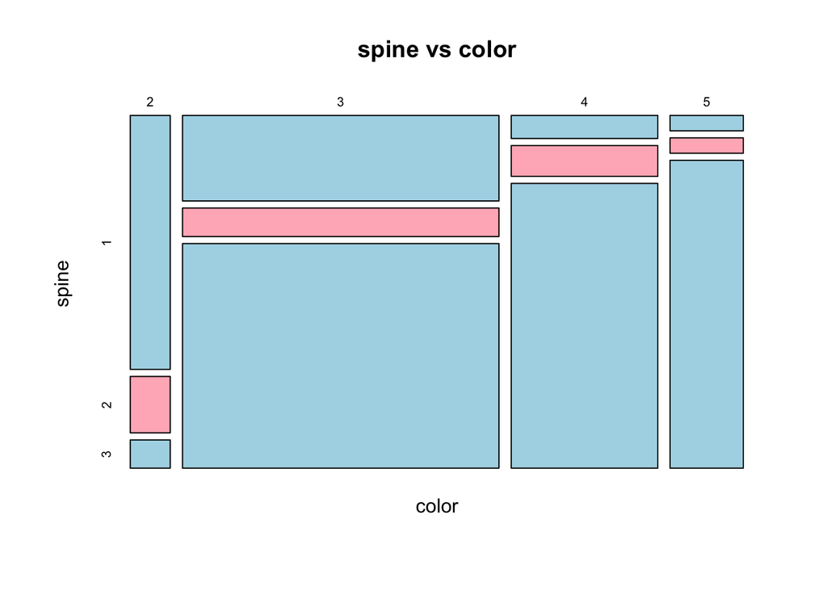

```
##
##    Cell Contents
## |-------------------------|
## |                   Count |
## |             Row Percent |
## |          Column Percent |
## |           Total Percent |
## |-------------------------|
##
## Total Observations in Table:  173
##
##              | spine
##        color |        1  |        2  |        3  | Row Total |
## -------------|-----------|-----------|-----------|-----------|
##            2 |        9  |        2  |        1  |       12  |
##              |   75.000% |   16.667% |    8.333% |    6.936% |
##              |   24.324% |   13.333% |    0.826% |           |
##              |    5.202% |    1.156% |    0.578% |           |
## -------------|-----------|-----------|-----------|-----------|
##            3 |       24  |        8  |       63  |       95  |
##              |   25.263% |    8.421% |   66.316% |   54.913% |
##              |   64.865% |   53.333% |   52.066% |           |
##              |   13.873% |    4.624% |   36.416% |           |
## -------------|-----------|-----------|-----------|-----------|
##            4 |        3  |        4  |       37  |       44  |
##              |    6.818% |    9.091% |   84.091% |   25.434% |
##              |    8.108% |   26.667% |   30.579% |           |
##              |    1.734% |    2.312% |   21.387% |           |
## -------------|-----------|-----------|-----------|-----------|
##            5 |        1  |        1  |       20  |       22  |
##              |    4.545% |    4.545% |   90.909% |   12.717% |
##              |    2.703% |    6.667% |   16.529% |           |
##              |    0.578% |    0.578% |   11.561% |           |
## -------------|-----------|-----------|-----------|-----------|
## Column Total |       37  |       15  |      121  |      173  |
##              |   21.387% |    8.671% |   69.942% |           |
## -------------|-----------|-----------|-----------|-----------|
##
##
```

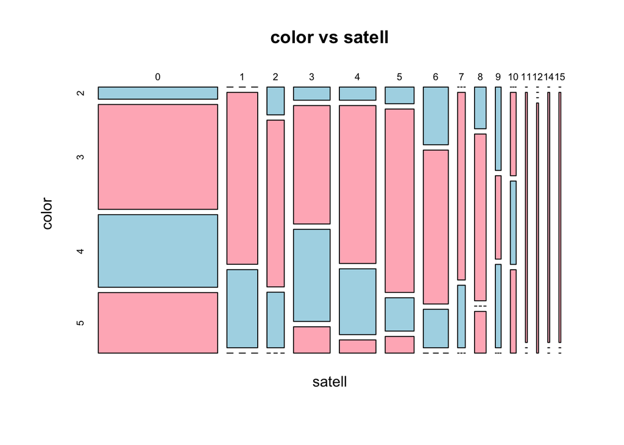

```
##
##    Cell Contents
## |-------------------------|
## |                   Count |
## |             Row Percent |
## |          Column Percent |
## |           Total Percent |
## |-------------------------|
##
## Total Observations in Table:  173
##
##              | color
##       satell |        2  |        3  |        4  |        5  | Row Total |
## -------------|-----------|-----------|-----------|-----------|-----------|
##            0 |        3  |       26  |       18  |       15  |       62  |
##              |    4.839% |   41.935% |   29.032% |   24.194% |   35.838% |
##              |   25.000% |   27.368% |   40.909% |   68.182% |           |
##              |    1.734% |   15.029% |   10.405% |    8.671% |           |
## -------------|-----------|-----------|-----------|-----------|-----------|
##            1 |        0  |       11  |        5  |        0  |       16  |
##              |    0.000% |   68.750% |   31.250% |    0.000% |    9.249% |
##              |    0.000% |   11.579% |   11.364% |    0.000% |           |
##              |    0.000% |    6.358% |    2.890% |    0.000% |           |
## -------------|-----------|-----------|-----------|-----------|-----------|
##            2 |        1  |        6  |        2  |        0  |        9  |
##              |   11.111% |   66.667% |   22.222% |    0.000% |    5.202% |
##              |    8.333% |    6.316% |    4.545% |    0.000% |           |
##              |    0.578% |    3.468% |    1.156% |    0.000% |           |
## -------------|-----------|-----------|-----------|-----------|-----------|
##            3 |        1  |        9  |        7  |        2  |       19  |
##              |    5.263% |   47.368% |   36.842% |   10.526% |   10.983% |
##              |    8.333% |    9.474% |   15.909% |    9.091% |           |
##              |    0.578% |    5.202% |    4.046% |    1.156% |           |
## -------------|-----------|-----------|-----------|-----------|-----------|
##            4 |        1  |       12  |        5  |        1  |       19  |
##              |    5.263% |   63.158% |   26.316% |    5.263% |   10.983% |
##              |    8.333% |   12.632% |   11.364% |    4.545% |           |
##              |    0.578% |    6.936% |    2.890% |    0.578% |           |
## -------------|-----------|-----------|-----------|-----------|-----------|
##            5 |        1  |       11  |        2  |        1  |       15  |
```

[output cut: 39 more lines]

```
##           14 |        0  |        1  |        0  |        0  |        1  |
##              |    0.000% |  100.000% |    0.000% |    0.000% |    0.578% |
##              |    0.000% |    1.053% |    0.000% |    0.000% |           |
##              |    0.000% |    0.578% |    0.000% |    0.000% |           |
## -------------|-----------|-----------|-----------|-----------|-----------|
##           15 |        0  |        1  |        0  |        0  |        1  |
##              |    0.000% |  100.000% |    0.000% |    0.000% |    0.578% |
##              |    0.000% |    1.053% |    0.000% |    0.000% |           |
##              |    0.000% |    0.578% |    0.000% |    0.000% |           |
## -------------|-----------|-----------|-----------|-----------|-----------|
## Column Total |       12  |       95  |       44  |       22  |      173  |
##              |    6.936% |   54.913% |   25.434% |   12.717% |           |
## -------------|-----------|-----------|-----------|-----------|-----------|
##
##
```

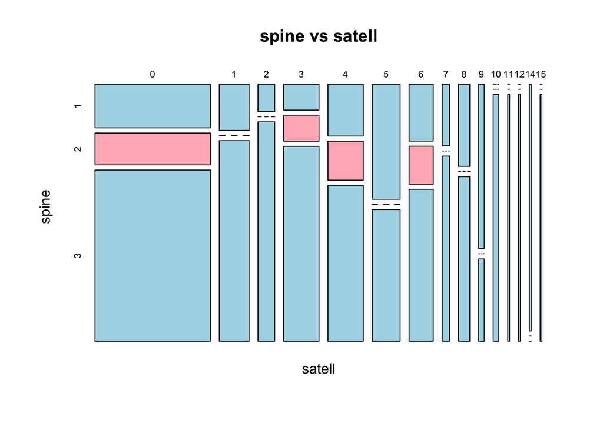

```
##
##    Cell Contents
## |-------------------------|
## |                   Count |
## |             Row Percent |
## |          Column Percent |
## |           Total Percent |
## |-------------------------|
##
## Total Observations in Table:  173
##
##              | spine
##       satell |        1  |        2  |        3  | Row Total |
## -------------|-----------|-----------|-----------|-----------|
##            0 |       11  |        8  |       43  |       62  |
##              |   17.742% |   12.903% |   69.355% |   35.838% |
##              |   29.730% |   53.333% |   35.537% |           |
##              |    6.358% |    4.624% |   24.855% |           |
## -------------|-----------|-----------|-----------|-----------|
##            1 |        3  |        0  |       13  |       16  |
##              |   18.750% |    0.000% |   81.250% |    9.249% |
##              |    8.108% |    0.000% |   10.744% |           |
##              |    1.734% |    0.000% |    7.514% |           |
## -------------|-----------|-----------|-----------|-----------|
##            2 |        1  |        0  |        8  |        9  |
##              |   11.111% |    0.000% |   88.889% |    5.202% |
##              |    2.703% |    0.000% |    6.612% |           |
##              |    0.578% |    0.000% |    4.624% |           |
## -------------|-----------|-----------|-----------|-----------|
##            3 |        2  |        2  |       15  |       19  |
##              |   10.526% |   10.526% |   78.947% |   10.983% |
##              |    5.405% |   13.333% |   12.397% |           |
##              |    1.156% |    1.156% |    8.671% |           |
## -------------|-----------|-----------|-----------|-----------|
##            4 |        4  |        3  |       12  |       19  |
##              |   21.053% |   15.789% |   63.158% |   10.983% |
##              |   10.811% |   20.000% |    9.917% |           |
##              |    2.312% |    1.734% |    6.936% |           |
## -------------|-----------|-----------|-----------|-----------|
##            5 |        7  |        0  |        8  |       15  |
```

[output cut: 39 more lines]

```
##           14 |        1  |        0  |        0  |        1  |
##              |  100.000% |    0.000% |    0.000% |    0.578% |
##              |    2.703% |    0.000% |    0.000% |           |
##              |    0.578% |    0.000% |    0.000% |           |
## -------------|-----------|-----------|-----------|-----------|
##           15 |        0  |        0  |        1  |        1  |
##              |    0.000% |    0.000% |  100.000% |    0.578% |
##              |    0.000% |    0.000% |    0.826% |           |
##              |    0.000% |    0.000% |    0.578% |           |
## -------------|-----------|-----------|-----------|-----------|
## Column Total |       37  |       15  |      121  |      173  |
##              |   21.387% |    8.671% |   69.942% |           |
## -------------|-----------|-----------|-----------|-----------|
##
##
```

```r
cual.col = c()
for (i in names(dc)) {
  if ("factor" %in% class(dc[,i])){
    cual.col = c(cual.col,i)
  }
}
library(gmodels)
m = matrix(ncol = 2)
for (i in cual.col) {
  for (j in cual.col) {
    if (i != j & j != "satell") {
      if (i %in% m[,2] & j %in% m[,1]){
        next
      }else{
        m = rbind(m,c(i,j))
        plot(table(dc[,i],dc[,j]), xlab = i, ylab = j,
             main = paste(j, "vs",i), col = c("lightblue","lightpink"))

        CrossTable(dc[,i],dc[,j], prop.chisq = FALSE, dnn = c(i,j),
                   format = "SPSS")
      }
    }
  }
}
```

#### Variables cualitativas y ordinales * Diagramas de barras

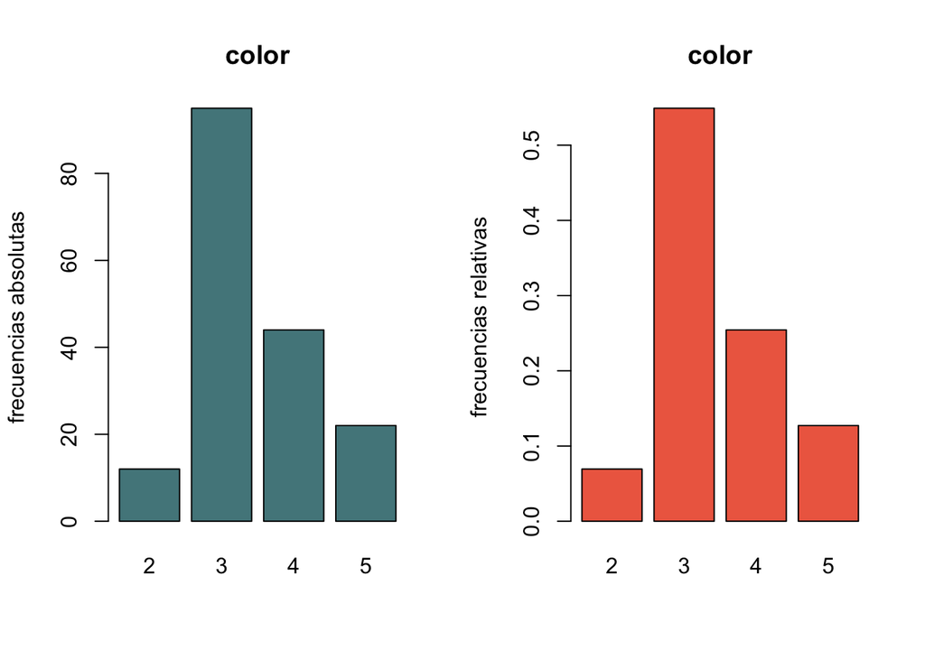

```
## [1] "Tabla de Frecuencias Absolutas"
##
##  2  3  4  5
## 12 95 44 22
## [1] "Tabla de Frecuencias Relativas"
##
##     2     3     4     5
## 0.069 0.549 0.254 0.127
```

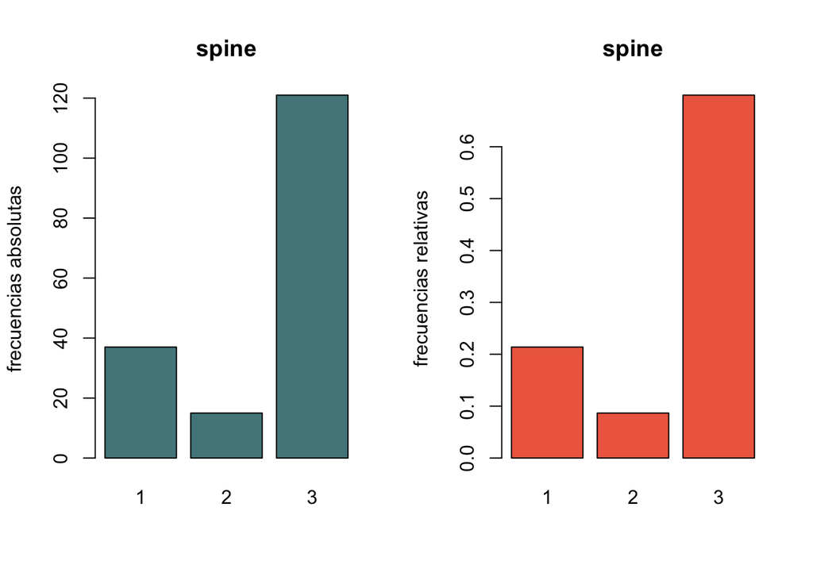

```
## [1] "Tabla de Frecuencias Absolutas"
##
##   1   2   3
##  37  15 121
## [1] "Tabla de Frecuencias Relativas"
##
##     1     2     3
## 0.214 0.087 0.699
```

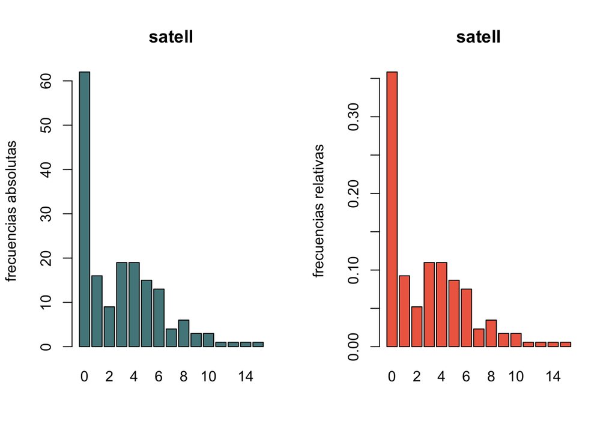

```
## [1] "Tabla de Frecuencias Absolutas"
##
##  0  1  2  3  4  5  6  7  8  9 10 11 12 14 15
## 62 16  9 19 19 15 13  4  6  3  3  1  1  1  1
## [1] "Tabla de Frecuencias Relativas"
##
##     0     1     2     3     4     5     6     7     8     9    10    11    12
## 0.358 0.092 0.052 0.110 0.110 0.087 0.075 0.023 0.035 0.017 0.017 0.006 0.006
##    14    15
## 0.006 0.006
```

```r
ord.col = c()
cuant.col=c()
for (n in names(dc)){
  if ("factor" %in% class(dc[,n])){
    par(mfrow=c(1,2))
    barplot(table(dc[,n]), main=n, ylab = "frecuencias absolutas",
         col="cadetblue4")
    barplot(prop.table(table(dc[,n])), main=n, ylab = "frecuencias relativas",
         col="coral2")
    tFact = table(dc[,n])
    tFact_rel = prop.table(table(dc[,n]))
    print("Tabla de Frecuencias Absolutas")
    print(tFact)
    print("Tabla de Frecuencias Relativas")
    print(round(tFact_rel,3))
#    CrossTable(dc[,n])
#    apply(dc[,n], FUN = table)
#    prop.table(table(dc[,n]))
  }else{
    cuant.col = c(cuant.col,n)
  }
}
```

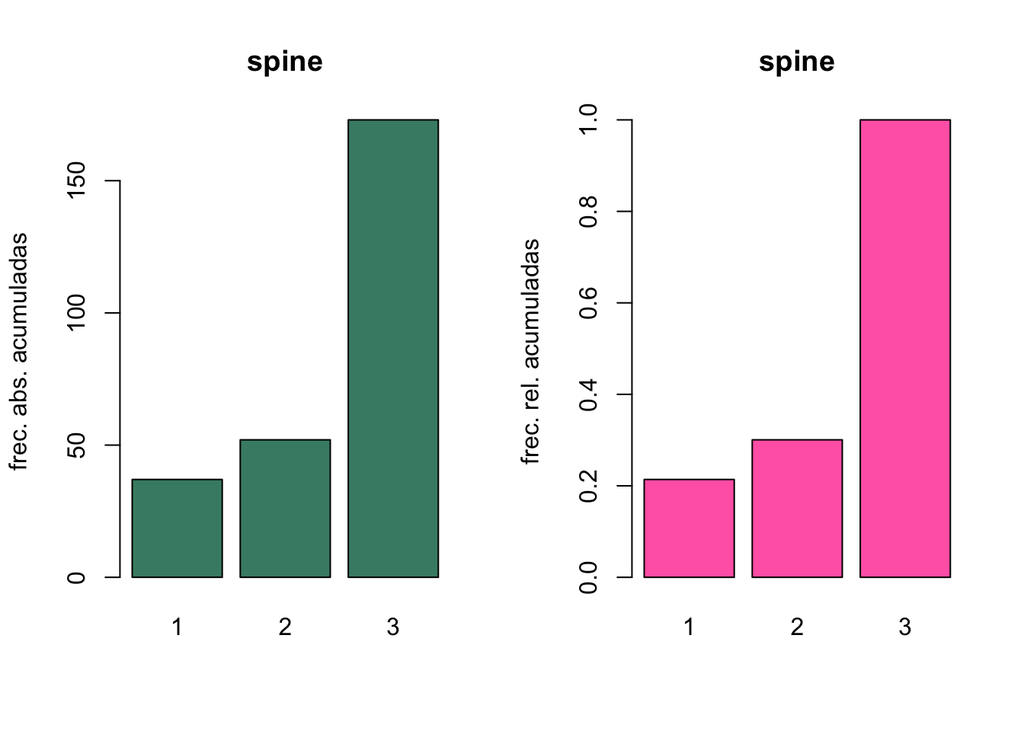

```
## [1] "Tabla de Frecuencias Absolutas Acumuladas"
##   1   2   3
##  37  52 173
## [1] "Tabla de Frecuencias Relativas Acumuladas"
##         1         2         3
## 0.2138728 0.3005780 1.0000000
```

```r
for (n in names(dc)){
  if ("ordered" %in% class(dc[,n])){
    ord.col = c(ord.col,n)
    barplot(cumsum(table(dc[,n])), main=n,
            ylab = "frec. abs. acumuladas",col="aquamarine4")
    barplot(cumsum(prop.table(table(dc[,n]))), main=n,
            ylab = "frec. rel. acumuladas",col="hotpink")
    tFact_Cum = cumsum(table(dc[,n]))
    tFact_rel_Cum = cumsum(prop.table(table(dc[,n])))
    print("Tabla de Frecuencias Absolutas Acumuladas")
    print(tFact_Cum)
    print("Tabla de Frecuencias Relativas Acumuladas")
    print(tFact_rel_Cum)
  }
}
```

#### Variables cuantitativas

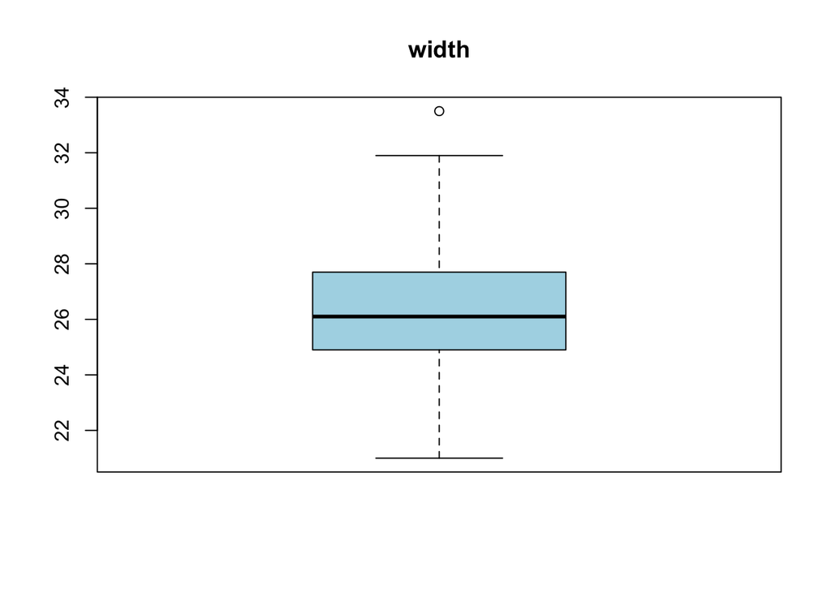

```
## [1] "Tabla Resumen de width"
##    Min. 1st Qu.  Median    Mean 3rd Qu.    Max.
##    21.0    24.9    26.1    26.3    27.7    33.5
```

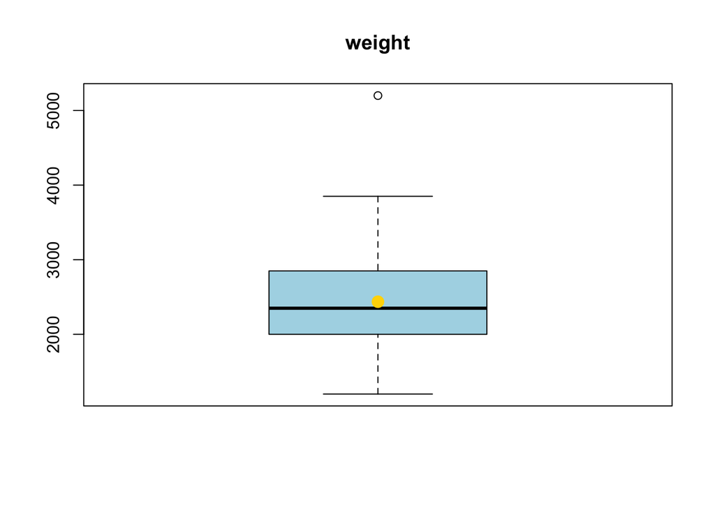

```
## [1] "Tabla Resumen de weight"
##    Min. 1st Qu.  Median    Mean 3rd Qu.    Max.
##    1200    2000    2350    2437    2850    5200
```

```r
#summary(dc[,cuant.col])
for (x in cuant.col) {
  boxplot(dc[,x], col = "lightblue", notch = FALSE, main = x)
  points(mean(dc[,n]), col = "gold", pch=19, cex = 1.5)
  summCuant = summary(dc[,x])
  print(sprintf("Tabla Resumen de %s",x))
  print(summCuant)
#  lapply(dc[,n], FUN = summary)
}
```

### AGRUPAR DATOS NUMERICOS

#### Peso frente a Ancho agrupado por colores

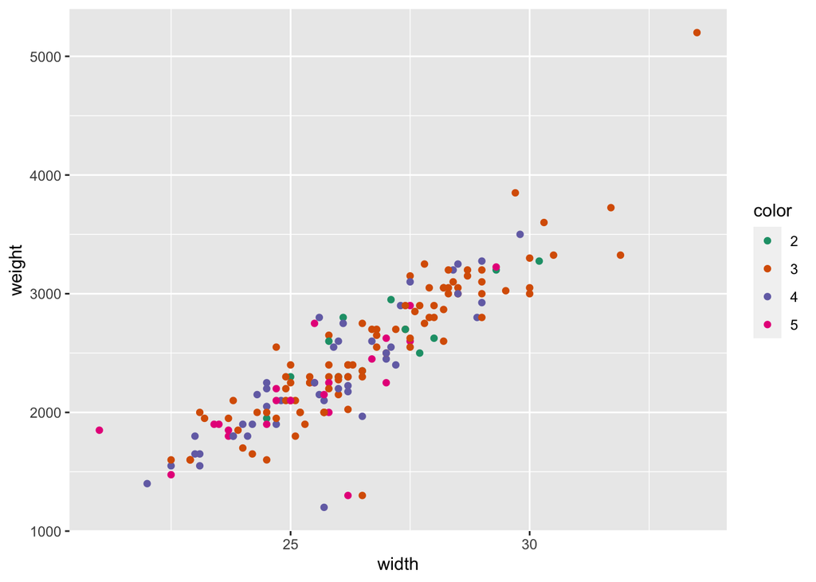

```r
library(ggplot2)
library(RColorBrewer)

# Crear escalas de colores
colorcolor = brewer.pal(4,"Dark2")
colorspine = brewer.pal(3,"Set1")
#No hay paletas de 15 colores

# el cuatro son los colores que se toman de dicha paleta
names(colorcolor) = levels(dc$color)
escalac = scale_color_manual(name = "color", values = colorcolor)

# Crear gráfico con la escala de colores personal:

p = ggplot(dc, aes(width,weight, colour = color)) +
  geom_point()
p + escalac
```

```r
#plot(dc$width,dc$weight, type = "p", main = "Peso Vs Ancho de los Cangrejos",
#     xlab = "Ancho", ylab = "Peso")
```

#### Agrupados por spine con colores

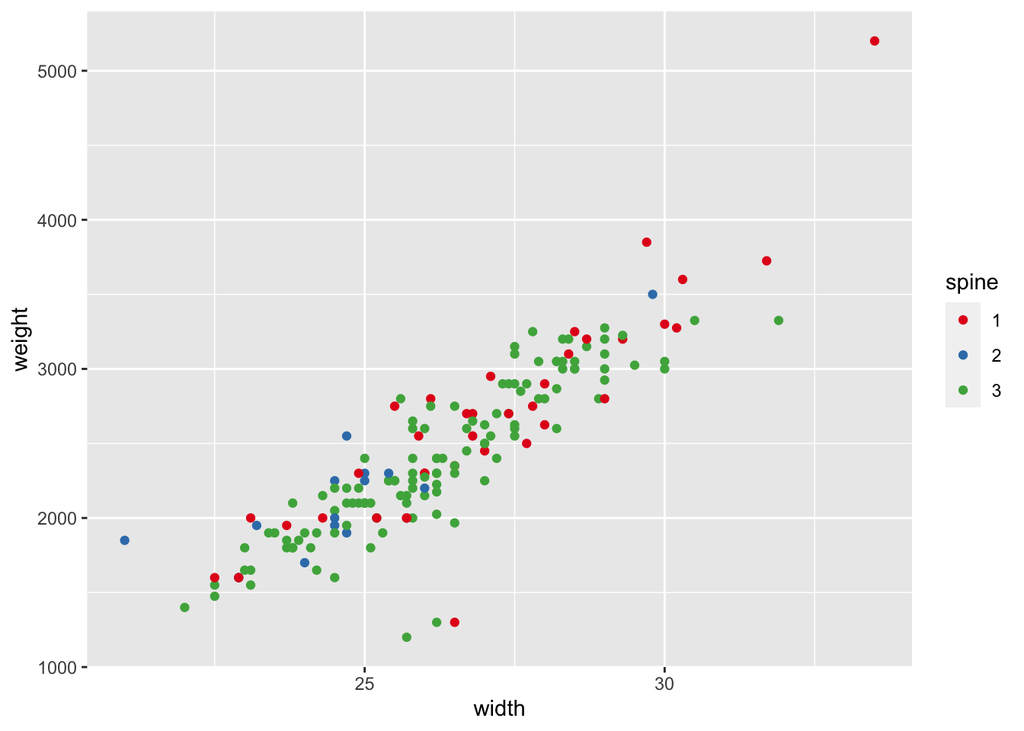

```r
# el cuatro son los colores que se toman de dicha paleta
names(colorspine) = levels(dc$spine)
escalasp = scale_color_manual(name = "spine", values = colorspine)

# Crear gráfico con la escala de colores personal:

psp = ggplot(dc, aes(width,weight, colour = spine)) +
  geom_point()
psp + escalasp
```

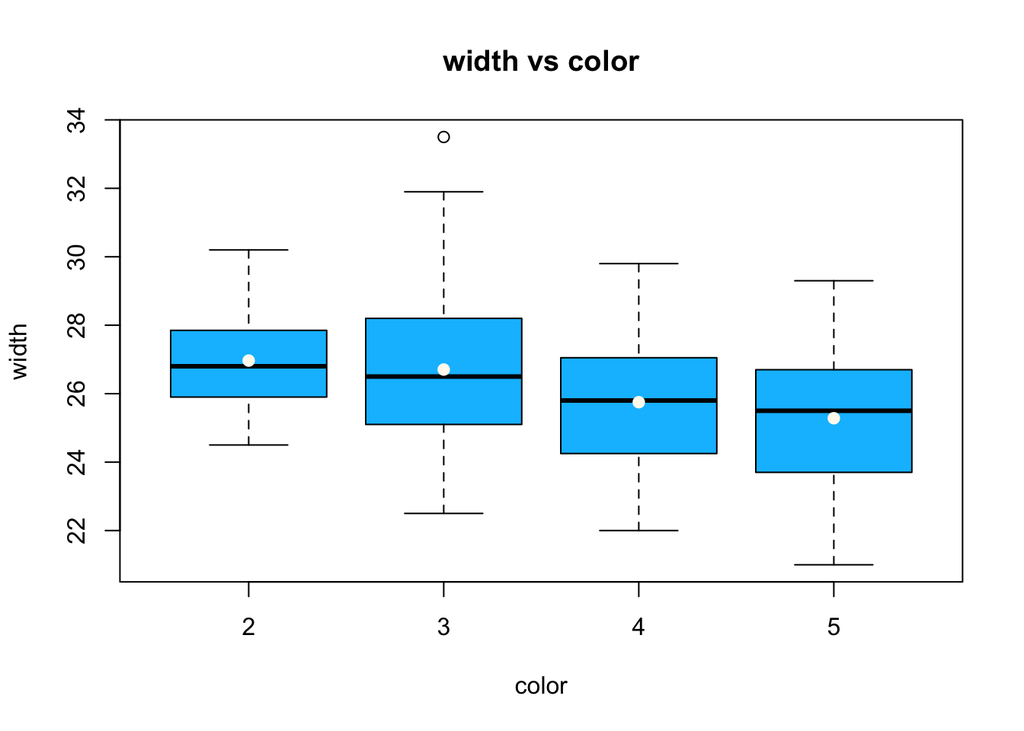

```
## dc[, j]: 2
##    Min. 1st Qu.  Median    Mean 3rd Qu.    Max.
##   24.50   25.95   26.80   26.97   27.77   30.20
## ------------------------------------------------------------
## dc[, j]: 3
##    Min. 1st Qu.  Median    Mean 3rd Qu.    Max.
##    22.5    25.1    26.5    26.7    28.2    33.5
## ------------------------------------------------------------
## dc[, j]: 4
##    Min. 1st Qu.  Median    Mean 3rd Qu.    Max.
##   22.00   24.27   25.80   25.75   27.02   29.80
## ------------------------------------------------------------
## dc[, j]: 5
##    Min. 1st Qu.  Median    Mean 3rd Qu.    Max.
##   21.00   23.90   25.50   25.28   26.57   29.30
```

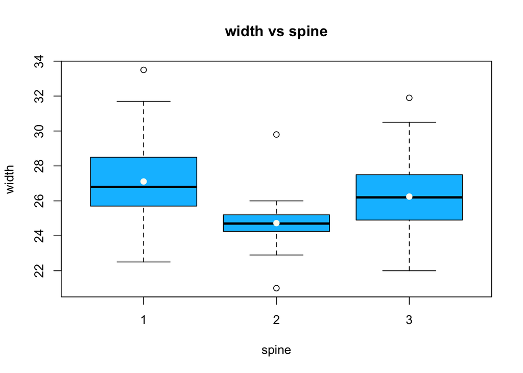

```
## dc[, j]: 1
##    Min. 1st Qu.  Median    Mean 3rd Qu.    Max.
##   22.50   25.70   26.80   27.11   28.50   33.50
## ------------------------------------------------------------
## dc[, j]: 2
##    Min. 1st Qu.  Median    Mean 3rd Qu.    Max.
##   21.00   24.25   24.70   24.73   25.20   29.80
## ------------------------------------------------------------
## dc[, j]: 3
##    Min. 1st Qu.  Median    Mean 3rd Qu.    Max.
##   22.00   24.90   26.20   26.25   27.50   31.90
```

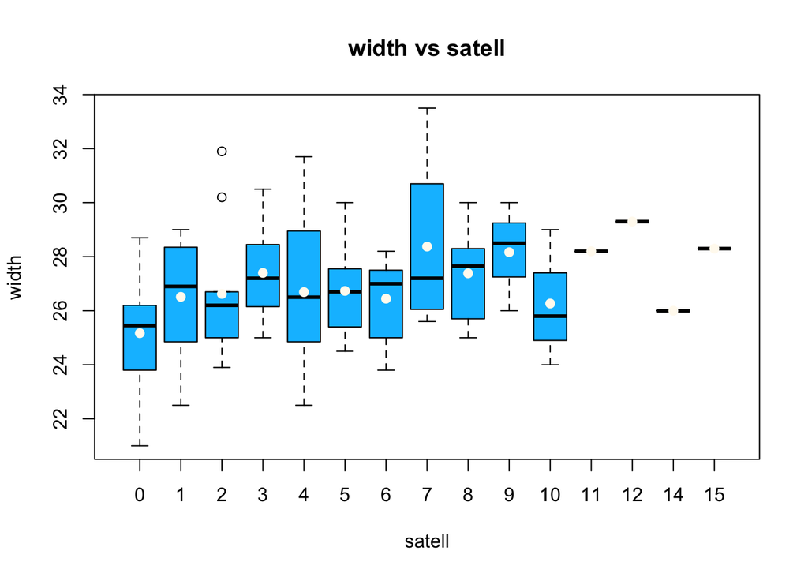

```
## dc[, j]: 0
##    Min. 1st Qu.  Median    Mean 3rd Qu.    Max.
##   21.00   23.85   25.45   25.17   26.20   28.70
## ------------------------------------------------------------
## dc[, j]: 1
##    Min. 1st Qu.  Median    Mean 3rd Qu.    Max.
##   22.50   25.02   26.90   26.51   28.27   29.00
## ------------------------------------------------------------
## dc[, j]: 2
##    Min. 1st Qu.  Median    Mean 3rd Qu.    Max.
##   23.90   25.00   26.20   26.62   26.70   31.90
## ------------------------------------------------------------
## dc[, j]: 3
##    Min. 1st Qu.  Median    Mean 3rd Qu.    Max.
##   25.00   26.15   27.20   27.40   28.45   30.50
## ------------------------------------------------------------
## dc[, j]: 4
##    Min. 1st Qu.  Median    Mean 3rd Qu.    Max.
##   22.50   24.85   26.50   26.69   28.95   31.70
## ------------------------------------------------------------
## dc[, j]: 5
##    Min. 1st Qu.  Median    Mean 3rd Qu.    Max.
##   24.50   25.40   26.70   26.73   27.55   30.00
## ------------------------------------------------------------
## dc[, j]: 6
##    Min. 1st Qu.  Median    Mean 3rd Qu.    Max.
##   23.80   25.00   27.00   26.45   27.50   28.20
## ------------------------------------------------------------
## dc[, j]: 7
##    Min. 1st Qu.  Median    Mean 3rd Qu.    Max.
##   25.60   26.27   27.20   28.38   29.30   33.50
## ------------------------------------------------------------
## dc[, j]: 8
##    Min. 1st Qu.  Median    Mean 3rd Qu.    Max.
##   25.00   26.05   27.65   27.38   28.27   30.00
## ------------------------------------------------------------
## dc[, j]: 9
##    Min. 1st Qu.  Median    Mean 3rd Qu.    Max.
##   26.00   27.25   28.50   28.17   29.25   30.00
## ------------------------------------------------------------
## dc[, j]: 10
##    Min. 1st Qu.  Median    Mean 3rd Qu.    Max.
##   24.00   24.90   25.80   26.27   27.40   29.00
## ------------------------------------------------------------
## dc[, j]: 11
##    Min. 1st Qu.  Median    Mean 3rd Qu.    Max.
##    28.2    28.2    28.2    28.2    28.2    28.2
## ------------------------------------------------------------
## dc[, j]: 12
##    Min. 1st Qu.  Median    Mean 3rd Qu.    Max.
##    29.3    29.3    29.3    29.3    29.3    29.3
## ------------------------------------------------------------
## dc[, j]: 14
##    Min. 1st Qu.  Median    Mean 3rd Qu.    Max.
##      26      26      26      26      26      26
## ------------------------------------------------------------
## dc[, j]: 15
##    Min. 1st Qu.  Median    Mean 3rd Qu.    Max.
##    28.3    28.3    28.3    28.3    28.3    28.3
```

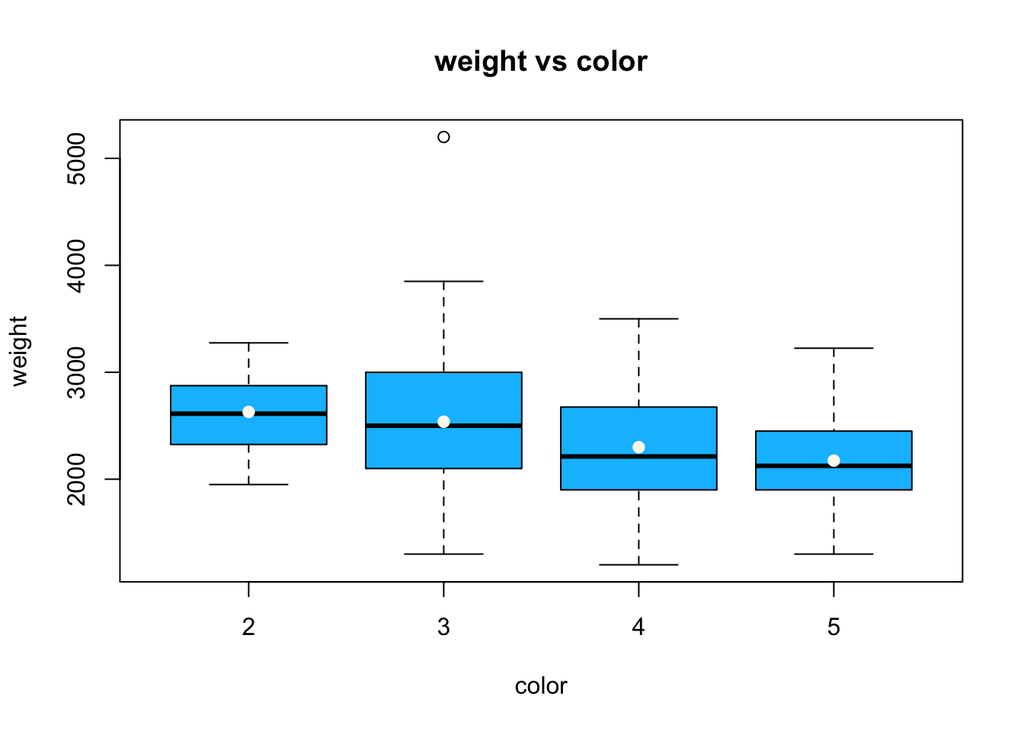

```
## dc[, j]: 2
##    Min. 1st Qu.  Median    Mean 3rd Qu.    Max.
##    1950    2338    2612    2629    2838    3275
## ------------------------------------------------------------
## dc[, j]: 3
##    Min. 1st Qu.  Median    Mean 3rd Qu.    Max.
##    1300    2100    2500    2538    3000    5200
## ------------------------------------------------------------
## dc[, j]: 4
##    Min. 1st Qu.  Median    Mean 3rd Qu.    Max.
##    1200    1900    2212    2299    2638    3500
## ------------------------------------------------------------
## dc[, j]: 5
##    Min. 1st Qu.  Median    Mean 3rd Qu.    Max.
##    1300    1900    2125    2174    2400    3225
```

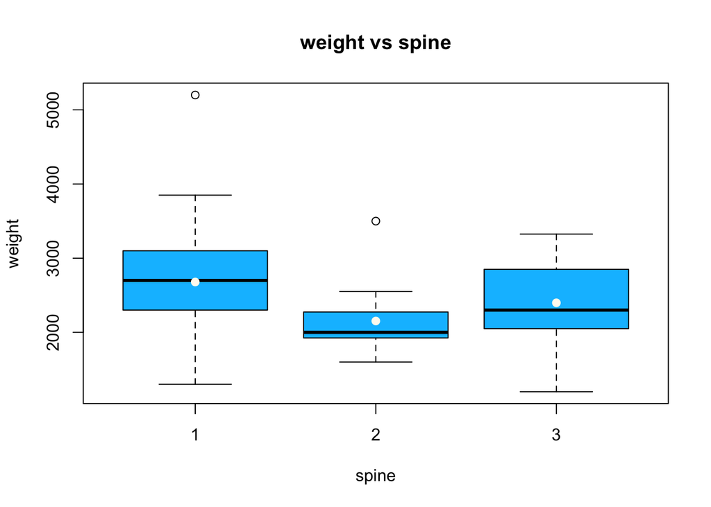

```
## dc[, j]: 1
##    Min. 1st Qu.  Median    Mean 3rd Qu.    Max.
##    1300    2300    2700    2679    3100    5200
## ------------------------------------------------------------
## dc[, j]: 2
##    Min. 1st Qu.  Median    Mean 3rd Qu.    Max.
##    1600    1925    2000    2153    2275    3500
## ------------------------------------------------------------
## dc[, j]: 3
##    Min. 1st Qu.  Median    Mean 3rd Qu.    Max.
##    1200    2050    2300    2398    2850    3325
```

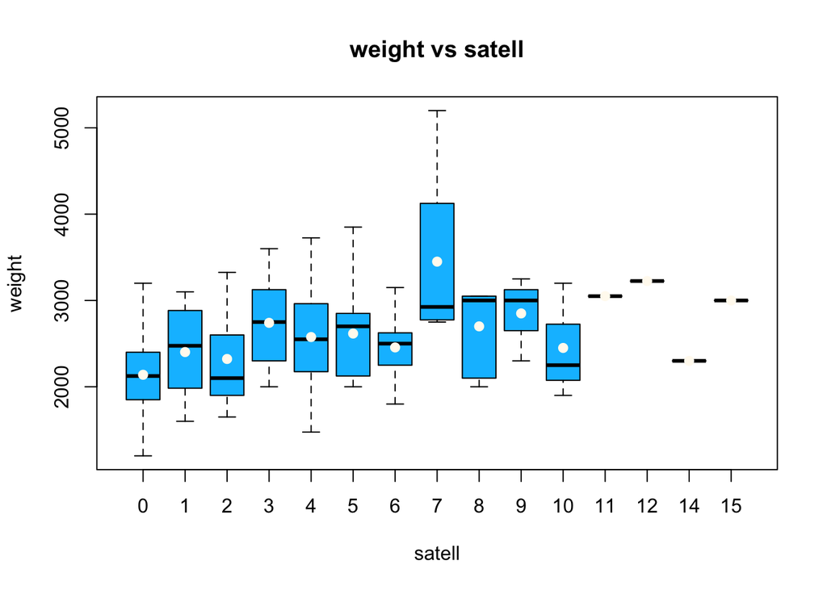

```
## dc[, j]: 0
##    Min. 1st Qu.  Median    Mean 3rd Qu.    Max.
##    1200    1850    2125    2139    2400    3200
## ------------------------------------------------------------
## dc[, j]: 1
##    Min. 1st Qu.  Median    Mean 3rd Qu.    Max.
##    1600    1992    2475    2402    2875    3100
## ------------------------------------------------------------
## dc[, j]: 2
##    Min. 1st Qu.  Median    Mean 3rd Qu.    Max.
##    1650    1900    2100    2322    2600    3325
## ------------------------------------------------------------
## dc[, j]: 3
##    Min. 1st Qu.  Median    Mean 3rd Qu.    Max.
##    2000    2300    2750    2741    3125    3600
## ------------------------------------------------------------
## dc[, j]: 4
##    Min. 1st Qu.  Median    Mean 3rd Qu.    Max.
##    1475    2175    2550    2576    2962    3725
## ------------------------------------------------------------
## dc[, j]: 5
##    Min. 1st Qu.  Median    Mean 3rd Qu.    Max.
##    2000    2125    2700    2617    2850    3850
## ------------------------------------------------------------
## dc[, j]: 6
##    Min. 1st Qu.  Median    Mean 3rd Qu.    Max.
##    1800    2250    2500    2456    2625    3150
## ------------------------------------------------------------
## dc[, j]: 7
##    Min. 1st Qu.  Median    Mean 3rd Qu.    Max.
##    2750    2788    2925    3450    3588    5200
## ------------------------------------------------------------
## dc[, j]: 8
##    Min. 1st Qu.  Median    Mean 3rd Qu.    Max.
##    2000    2312    3000    2700    3050    3050
## ------------------------------------------------------------
## dc[, j]: 9
##    Min. 1st Qu.  Median    Mean 3rd Qu.    Max.
##    2300    2650    3000    2850    3125    3250
## ------------------------------------------------------------
## dc[, j]: 10
##    Min. 1st Qu.  Median    Mean 3rd Qu.    Max.
##    1900    2075    2250    2450    2725    3200
## ------------------------------------------------------------
## dc[, j]: 11
##    Min. 1st Qu.  Median    Mean 3rd Qu.    Max.
##    3050    3050    3050    3050    3050    3050
## ------------------------------------------------------------
## dc[, j]: 12
##    Min. 1st Qu.  Median    Mean 3rd Qu.    Max.
##    3225    3225    3225    3225    3225    3225
## ------------------------------------------------------------
## dc[, j]: 14
##    Min. 1st Qu.  Median    Mean 3rd Qu.    Max.
##    2300    2300    2300    2300    2300    2300
## ------------------------------------------------------------
## dc[, j]: 15
##    Min. 1st Qu.  Median    Mean 3rd Qu.    Max.
##    3000    3000    3000    3000    3000    3000
```

```r
for (i in cuant.col) {
  for (j in cual.col) {
#    tSum = aggregate(dc[,i]~dc[,j], FUN = summary)
    boxplot(dc[,i]~dc[,j], col = "deepskyblue",
            main = paste(i,"vs",j),
            ylab = i, xlab = j)
    medias = aggregate(dc[,i]~dc[,j], FUN = mean)
    points(medias, col = "floralwhite", pch = 19)
#    summary(dc[,i],dc[,j])
#    j = factor(dc[,j])
    tSum = by(dc[,i],dc[,j], FUN = summary)
#    tSum = by(dc[,i],j, FUN = summary)

    print(tSum)
  }
}
```

```r
# by(dc[,cuant.col],dc[,"color"], FUN = summary)
# by(dc[,cuant.col],dc[,"spine"], FUN = summary)
# by(dc[,cuant.col],dc[,"satell"], FUN = summary)
```

## DUDAS

- ¿tengo que convertir las variables categoricas a factores en R? creo que si… sobre todo si son ordinales, pero no lo tengo claro… lo voy haciendo con la función factor y ordered=TRUE Vale, al convertirlos a factores ordenados la función summary me devuelve las frecuencias absolutas de los mismos.
- ¿cómo se hacen todas las tablas de una vez para todas las variables categoricas en R? RESUELTO
- ¿Cómo seleccionar diferentes colores según las categorías de un factor? más o menos resuelto, ver chunk de coloresAgrupados
- ¿cómo puedo añadir filas totales y frecuencias relativas con la funcion ftable?
- ¿Por que no me salen las tablas agrupas por by o aggregate con los bucles for? - RESUELTO. me faltaba añadirlo a una variable y hacerle un print, con aggregate sigue sin funcionar
- ¿Como hacer tablas para los datos cualitativos? ¿Que no sean ni tablas de frecuencias, ni summary? ¿Serán los histogramas? (interesa detectar los outliers)
- ¿Cómo se le puede poner titulo a las tablas de summary?
- ¿Se puede mejorar la estetica de la tabla de función gmodels::crosstable?
- ¿cómo puedo hacer para que no se me repitan los diagramas de mosaico, color spine, spine color? - RESUELTO
- ¿se puede ajustar el ylim del gráfico dentro del bucle for?
- Cómo puedo hacer para que me salgan juntos los diagramas de las variables ordinales: frecuencias y acumuladas?
- ¿Cómo puedo cambiar los nombres de las listas de las tablas summary en los diagramas de bigotes agrupados? - Probar con las funciones aggregate y head